# Hands-on 1: How to create a fMRI preprocessing workflow

The purpose of this section is that you set-up a complete fMRI analysis workflow yourself. So that in the end you are able to perform the analysis from A-Z, i.e. from preprocessing to group analysis. This section will cover the preprocessing part, and the section Hands-on 2: Analysis will handle the analysis part.

We will use this opportunity to show you some nice additional interfaces/nodes that might not be relevant to your usual analysis. But it's always nice to know that they exist. And hopefully, this will encourage you to investigate all other interfaces that Nipype can bring to the tip of your finger.

## Preparation

Before we can start with anything we first need to download the data. For this hands-on, we will only use the right-handed subjects 2-4 and 7-9. This can be done very quickly with the following `datalad` command.

**Note:** This might take a while, as datalad needs to download ~200MB of data

```python
%%bash
datalad get -J 4 /data/ds000114/sub-0[234789]/ses-test/anat/sub-0[234789]_ses-test_T1w.nii.gz \
                /data/ds000114/sub-0[234789]/ses-test/func/*fingerfootlips*
```

```
get(notneeded): /data/ds000114/sub-02/ses-test/anat/sub-02_ses-test_T1w.nii.gz (file) [already present]
get(notneeded): /data/ds000114/sub-03/ses-test/anat/sub-03_ses-test_T1w.nii.gz (file) [already present]
get(notneeded): /data/ds000114/sub-04/ses-test/anat/sub-04_ses-test_T1w.nii.gz (file) [already present]
get(notneeded): /data/ds000114/sub-07/ses-test/anat/sub-07_ses-test_T1w.nii.gz (file) [already present]
get(notneeded): /data/ds000114/sub-08/ses-test/anat/sub-08_ses-test_T1w.nii.gz (file) [already present]
get(notneeded): /data/ds000114/sub-09/ses-test/anat/sub-09_ses-test_T1w.nii.gz (file) [already present]
get(notneeded): /data/ds000114/sub-02/ses-test/func/sub-02_ses-test_task-fingerfootlips_bold.nii.gz (file) [already present]
get(notneeded): /data/ds000114/sub-03/ses-test/func/sub-03_ses-test_task-fingerfootlips_bold.nii.gz (file) [already present]
get(notneeded): /data/ds000114/sub-04/ses-test/func/sub-04_ses-test_task-fingerfootlips_bold.nii.gz (file) [already present]
get(notneeded): /data/ds000114/sub-07/ses-test/func/sub-07_ses-test_task-fingerfootlips_bold.nii.gz (file) [already present]
get(notneeded): /data/ds000114/sub-08/ses-test/func/sub-08_ses-test_task-fingerfootlips_bold.nii.gz (file) [already present]
get(notneeded): /data/ds000114/sub-09/ses-test/func/sub-09_ses-test_task-fingerfootlips_bold.nii.gz (file) [already present]
action summary:
  get (notneeded: 12)
```

# Preprocessing Workflow Structure

So let's get our hands dirty. First things first, it's always good to know which interfaces you want to use in your workflow and in which order you want to execute them. For the preprocessing workflow, I recommend that we use the following nodes:

[output not shown]

**Note:** This workflow might be overkill concerning data manipulation, but it hopefully serves as a good Nipype exercise.

## Imports

It's always best to have all relevant module imports at the beginning of your script. So let's import what we most certainly need.

```python
# Get the Node and Workflow object
from nipype import Node, Workflow

# Specify which SPM to use
from nipype.interfaces.matlab import MatlabCommand
MatlabCommand.set_default_paths('/opt/spm12-r7219/spm12_mcr/spm12')
```

**Note:** Ideally you would also put the imports of all the interfaces that you use here at the top. But as we will develop the workflow step by step, we can also import the relevant modules as we go.

## Create Nodes and Workflow connections

Let's create all the nodes that we need! Make sure to specify all relevant inputs and keep in mind which ones you later on need to connect in your pipeline.

### Workflow

We recommend to create the workflow and establish all its connections at a later place in your script. This helps to have everything nicely together. But for this hands-on example it makes sense to establish the connections between the nodes as we go.

And for this, we first need to create a workflow:

```python
# Create the workflow here
# Hint: use 'base_dir' to specify where to store the working directory
```

```python
preproc = Workflow(name='work_preproc', base_dir='/output/')
```

### Gunzip

I've already created the `Gunzip` node as a template for the other nodes. Also, we've specified an `in_file` here so that we can directly test the nodes without worrying about the Input/Output data stream to the workflow. This will be taken care of in a later section.

```python
from nipype.algorithms.misc import Gunzip
```

```python
# Specify example input file
func_file = '/data/ds000114/sub-07/ses-test/func/sub-07_ses-test_task-fingerfootlips_bold.nii.gz'

# Initiate Gunzip node
gunzip_func = Node(Gunzip(in_file=func_file), name='gunzip_func')
```

### Drop Dummy Scans

The functional images of this dataset were recorded with 4 dummy scans at the beginning (see the [corresponding publication](https://www.ncbi.nlm.nih.gov/pmc/articles/PMC3641991/)). But those dummy scans were not yet taken out from the functional images.

To better illustrate this, let's plot the time course of a random voxel of the just defined `func_file`:

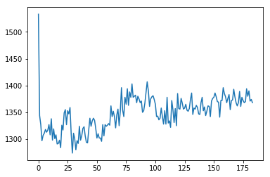

```python
%matplotlib inline
import pylab as plt
import nibabel as nb
plt.plot(nb.load(func_file).get_fdata()[32, 32, 15, :]);
```

In the figure above, we see that at the very beginning there are extreme values, which hint to the fact that steady state wasn't reached yet. Therefore, we want to exclude the dummy scans from the original data. This can be achieved with FSL's `ExtractROI`.

```python
from nipype.interfaces.fsl import ExtractROI
```

```python
extract = Node(ExtractROI(t_min=4, t_size=-1, output_type='NIFTI'),
               name="extract")
```

This `ExtractROI` node can now be connected to the `gunzip_func` node from above. To do this, we use the following command:

```python
preproc.connect([(gunzip_func, extract, [('out_file', 'in_file')])])
```

### Slice Time Correction

Now to the next step. Let's us SPM's `SliceTiming` to correct for slice wise acquisition of the volumes. As a reminder, the tutorial dataset was recorded...

- with a time repetition (TR) of 2.5 seconds
- with 30 slices per volume
- in an interleaved fashion, i.e. slice order is [1, 3, 5, 7, ..., 2, 4, 6, ..., 30]
- with a time acquisition (TA) of 2.4167 seconds, i.e. `TR-(TR/num_slices)`

```python
from nipype.interfaces.spm import SliceTiming
```

```python
slice_order = list(range(1, 31, 2)) + list(range(2, 31, 2))
print(slice_order)
```

```
[1, 3, 5, 7, 9, 11, 13, 15, 17, 19, 21, 23, 25, 27, 29, 2, 4, 6, 8, 10, 12, 14, 16, 18, 20, 22, 24, 26, 28, 30]
```

```python
# Initiate SliceTiming node here
```

```python
slicetime = Node(SliceTiming(num_slices=30,
                             ref_slice=15,
                             slice_order=slice_order,
                             time_repetition=2.5,
                             time_acquisition=2.5-(2.5/30)),
                 name='slicetime')
```

Now the next step is to connect the `SliceTiming` node to the rest of the workflow, i.e. the `ExtractROI` node.

```python
# Connect SliceTiming node to the other nodes here
```

```python
preproc.connect([(extract, slicetime, [('roi_file', 'in_files')])])
```

### Motion Correction

To correct for motion in the scanner, we will be using FSL's `MCFLIRT`.

```python
from nipype.interfaces.fsl import MCFLIRT
```

```python
# Initiate MCFLIRT node here
```

```python
mcflirt = Node(MCFLIRT(mean_vol=True,
                       save_plots=True),
               name="mcflirt")
```

Connect the `MCFLIRT` node to the rest of the workflow.

```python
# Connect MCFLIRT node to the other nodes here
```

```python
preproc.connect([(slicetime, mcflirt, [('timecorrected_files', 'in_file')])])
```

### Artifact Detection

We will use the really cool and useful `ArtifactDetection` tool from Nipype to detect motion and intensity outliers in the functional images. The interface is initiated as follows:

```python
from nipype.algorithms.rapidart import ArtifactDetect
```

```python
art = Node(ArtifactDetect(norm_threshold=2,
                          zintensity_threshold=2,
                          mask_type='spm_global',
                          parameter_source='FSL',
                          use_differences=[True, False],
                          plot_type='svg'),
           name="art")
```

The parameters above mean the following:

- `norm_threshold` - Threshold to use to detect motion-related outliers when composite motion is being used
- `zintensity_threshold` - Intensity Z-threshold use to detection images that deviate from the mean
- `mask_type` - Type of mask that should be used to mask the functional data. *spm_global* uses an spm_global like calculation to determine the brain mask
- `parameter_source` - Source of movement parameters
- `use_differences` - If you want to use differences between successive motion (first element) and intensity parameter (second element) estimates in order to determine outliers

And this is how you connect this node to the rest of the workflow:

```python
preproc.connect([(mcflirt, art, [('out_file', 'realigned_files'),
                                 ('par_file', 'realignment_parameters')])
                 ])
```

### Segmentation of anatomical image

Now let's work on the anatomical image. In particular, let's use SPM's `NewSegment` to create probability maps for the gray matter, white matter tissue and CSF.

```python
from nipype.interfaces.spm import NewSegment
```

```python
# Use the following tissue specification to get a GM and WM probability map
tpm_img ='/opt/spm12-r7219/spm12_mcr/spm12/tpm/TPM.nii'
tissue1 = ((tpm_img, 1), 1, (True,False), (False, False))
tissue2 = ((tpm_img, 2), 1, (True,False), (False, False))
tissue3 = ((tpm_img, 3), 2, (True,False), (False, False))
tissue4 = ((tpm_img, 4), 3, (False,False), (False, False))
tissue5 = ((tpm_img, 5), 4, (False,False), (False, False))
tissue6 = ((tpm_img, 6), 2, (False,False), (False, False))
tissues = [tissue1, tissue2, tissue3, tissue4, tissue5, tissue6]
```

```python
# Initiate NewSegment node here
```

```python
segment = Node(NewSegment(tissues=tissues), name='segment')
```

We will again be using a `Gunzip` node to unzip the anatomical image that we then want to use as input to the segmentation node. We again also need to specify the anatomical image that we want to use in this case. As before, this will later also be handled directly by the Input/Output stream.

```python
# Specify example input file
anat_file = '/data/ds000114/sub-07/ses-test/anat/sub-07_ses-test_T1w.nii.gz'

# Initiate Gunzip node
gunzip_anat = Node(Gunzip(in_file=anat_file), name='gunzip_anat')
```

Now we can connect the `NewSegment` node to the rest of the workflow.

```python
# Connect NewSegment node to the other nodes here
```

```python
preproc.connect([(gunzip_anat, segment, [('out_file', 'channel_files')])])
```

### Compute Coregistration Matrix

As a next step, we will make sure that the functional images are coregistered to the anatomical image. For this, we will use FSL's `FLIRT` function. As we just created a white matter probability map, we can use this together with the a Boundary-Based Registration (BBR) cost function do optimize the image coregistration. As some helpful notes...

- use a degree of freedom of 6
- specify the cost function as `bbr`
- use the `schedule='/usr/share/fsl/5.0/etc/flirtsch/bbr.sch'`

```python
from nipype.interfaces.fsl import FLIRT
```

```python
# Initiate FLIRT node here
```

```python
coreg = Node(FLIRT(dof=6,
                   cost='bbr',
                   schedule='/usr/share/fsl/5.0/etc/flirtsch/bbr.sch',
                   output_type='NIFTI'),
             name="coreg")
```

```python
# Connect FLIRT node to the other nodes here
```

```python
preproc.connect([(gunzip_anat, coreg, [('out_file', 'reference')]),
                 (mcflirt, coreg, [('mean_img', 'in_file')])
                 ])
```

As mentioned above, the `bbr` routine can use the subject-specific white matter probability map to guide the coregistration. But for this, we need to create a binary mask out of the WM probability map. This can easily be done by FSL's `Threshold` interface.

```python
from nipype.interfaces.fsl import Threshold

# Threshold - Threshold WM probability image
threshold_WM = Node(Threshold(thresh=0.5,
                              args='-bin',
                              output_type='NIFTI'),
                name="threshold_WM")
```

```python
# Select WM segmentation file from segmentation output
def get_wm(files):
    return files[1][0]

# Connecting the segmentation node with the threshold node
preproc.connect([(segment, threshold_WM, [(('native_class_images', get_wm),
                                           'in_file')])])
```

Now we can just connect this `Threshold` node to the coregistration node from above.

```python
# Connect Threshold node to coregistration node above here
```

```python
preproc.connect([(threshold_WM, coreg, [('out_file', 'wm_seg')])])
```

### Apply Coregistration Matrix to functional image

Now that we know the coregistration matrix to correctly overlay the functional mean image on the subject-specific anatomy, we need to apply to coregistration to the whole time series. This can be achieved with FSL's `FLIRT` as follows:

```python
# Specify the isometric voxel resolution you want after coregistration
desired_voxel_iso = 4

# Apply coregistration warp to functional images
applywarp = Node(FLIRT(interp='spline',
                       apply_isoxfm=desired_voxel_iso,
                       output_type='NIFTI'),
                 name="applywarp")
```

**Important**: As you can see above, we also specified a variable `desired_voxel_iso`. This is very important at this stage, otherwise `FLIRT` will transform your functional images to a resolution of the anatomical image, which will dramatically increase the file size (e.g. to 1-10GB per file). If you don't want to change the voxel resolution, use the additional parameter `no_resample=True`. Important, for this to work, you still need to define `apply_isoxfm=desired_voxel_iso`.

```python
# Connecting the ApplyWarp node to all the other nodes
preproc.connect([(mcflirt, applywarp, [('out_file', 'in_file')]),
                 (coreg, applywarp, [('out_matrix_file', 'in_matrix_file')]),
                 (gunzip_anat, applywarp, [('out_file', 'reference')])
                 ])
```

### Smoothing

Next step is image smoothing. The most simple way to do this is to use FSL's or SPM's `Smooth` function. But for learning purposes, let's use FSL's `SUSAN` workflow as it is implemented in Nipype. Note that this time, we are importing a workflow instead of an interface.

```python
from nipype.workflows.fmri.fsl.preprocess import create_susan_smooth
```

If you type `create_susan_smooth?` you can see how to specify the input variables to the susan workflow. In particular, they are...

- `fwhm`: set this value to 4 (or whichever value you want)
- `mask_file`: will be created in a later step
- `in_file`: will be handled while connection to other nodes in the preproc workflow

```python
# Initiate SUSAN workflow here
```

```python
susan = create_susan_smooth(name='susan')
susan.inputs.inputnode.fwhm = 4
```

```python
# Connect Threshold node to coregistration node above here
```

```python
preproc.connect([(applywarp, susan, [('out_file', 'inputnode.in_files')])])
```

### Create Binary Mask

There are many possible approaches on how you can mask your functional images. One of them is not at all, one is with a simple brain mask and one that only considers certain kind of brain tissue, e.g. gray matter.

For the current example, we want to create a dilated gray matter mask. For this purpose we need to:

1. Resample the gray matter probability map to the same resolution as the functional images
2. Threshold this resampled probability map at a specific value
3. Dilate this mask by some voxels to make the mask less conservative and more inclusive

The first step can be done in many ways (eg. using freesurfer's `mri_convert`, `nibabel`) but in our case, we will use FSL's `FLIRT`. The trick is to use the probability mask, as input file and a reference file.

```python
from nipype.interfaces.fsl import FLIRT

# Initiate resample node
resample = Node(FLIRT(apply_isoxfm=desired_voxel_iso,
                      output_type='NIFTI'),
                name="resample")
```

The second and third step can luckily be done with just one node. We can take almost the same `Threshold` node as above. We just need to add another additional argument: `-dilF` - which applies a maximum filtering of all voxels.

```python
from nipype.interfaces.fsl import Threshold

# Threshold - Threshold GM probability image
mask_GM = Node(Threshold(thresh=0.5,
                         args='-bin -dilF',
                         output_type='NIFTI'),
                name="mask_GM")

# Select GM segmentation file from segmentation output
def get_gm(files):
    return files[0][0]
```

Now we can connect the resample and the gray matter mask node to the segmentation node and each other.

```python
preproc.connect([(segment, resample, [(('native_class_images', get_gm), 'in_file'),
                                      (('native_class_images', get_gm), 'reference')
                                      ]),
                 (resample, mask_GM, [('out_file', 'in_file')])
                 ])
```

This should do the trick.

### Apply the binary mask

Now we can connect this dilated gray matter mask to the susan node, as well as actually applying this to the resulting smoothed images.

```python
# Connect gray matter Mask node to the susan workflow here
```

```python
preproc.connect([(mask_GM, susan, [('out_file', 'inputnode.mask_file')])])
```

To apply the mask to the smoothed functional images, we will use FSL's `ApplyMask` interface.

```python
from nipype.interfaces.fsl import ApplyMask
```

**Important:** The susan workflow gives out a list of files, i.e. `[smoothed_func.nii]` instead of just the filename directly. If we would use a normal `Node` for `ApplyMask` this would lead to the following error:

```
TraitError: The 'in_file' trait of an ApplyMaskInput instance must be an existing file name, but a value of ['/output/work_preproc/susan/smooth/mapflow/_smooth0/asub-07_ses-test_task-fingerfootlips_bold_mcf_flirt_smooth.nii.gz'] <class 'list'> was specified.
```

To prevent this we will be using a `MapNode` and specify the `in_file` as it's iterfield. Like this, the node is capable to handle a list of inputs as it will know that it has to apply itself iteratively to the list of inputs.

```python
from nipype import MapNode
```

```python
# Initiate ApplyMask node here
```

```python
mask_func = MapNode(ApplyMask(output_type='NIFTI'),
                    name="mask_func",
                    iterfield=["in_file"])
```

```python
# Connect smoothed susan output file to ApplyMask node here
```

```python
preproc.connect([(susan, mask_func, [('outputnode.smoothed_files', 'in_file')]),
                 (mask_GM, mask_func, [('out_file', 'mask_file')])
                 ])
```

### Remove linear trends in functional images

Last but not least. Let's use Nipype's `TSNR` module to remove linear and quadratic trends in the functionally smoothed images. For this, you only have to specify the `regress_poly` parameter in the node initiation.

```python
from nipype.algorithms.confounds import TSNR
```

```python
# Initiate TSNR node here
```

```python
detrend = Node(TSNR(regress_poly=2), name="detrend")
```

```python
# Connect the detrend node to the other nodes here
```

```python
preproc.connect([(mask_func, detrend, [('out_file', 'in_file')])])
```

## Datainput with `SelectFiles` and `iterables`

This is all nice and well. But so far we still had to specify the input values for `gunzip_anat` and `gunzip_func` ourselves. How can we scale this up to multiple subjects and/or multiple functional images and make the workflow take the input directly from the BIDS dataset?

For this, we need `SelectFiles` and `iterables`! It's rather simple, specify a template and fill-up the placeholder variables.

```python
# Import the SelectFiles
from nipype import SelectFiles

# String template with {}-based strings
templates = {'anat': 'sub-{subject_id}/ses-{ses_id}/anat/'
                     'sub-{subject_id}_ses-test_T1w.nii.gz',
             'func': 'sub-{subject_id}/ses-{ses_id}/func/'
                     'sub-{subject_id}_ses-{ses_id}_task-{task_id}_bold.nii.gz'}

# Create SelectFiles node
sf = Node(SelectFiles(templates,
                      base_directory='/data/ds000114',
                      sort_filelist=True),
          name='selectfiles')
sf.inputs.ses_id='test'
sf.inputs.task_id='fingerfootlips'
```

```python
subject_list = ['07']
sf.iterables = [('subject_id', subject_list)]
```

```python
# Connect SelectFiles node to the other nodes here
```

```python
preproc.connect([(sf, gunzip_anat, [('anat', 'in_file')]),
                 (sf, gunzip_func, [('func', 'in_file')])])
```

## Visualize the workflow

Now that we're done. Let's look at the workflow that we just created.

```
180514-09:56:56,605 workflow INFO:
	 Generated workflow graph: /output/work_preproc/graph.png (graph2use=colored, simple_form=True).
```

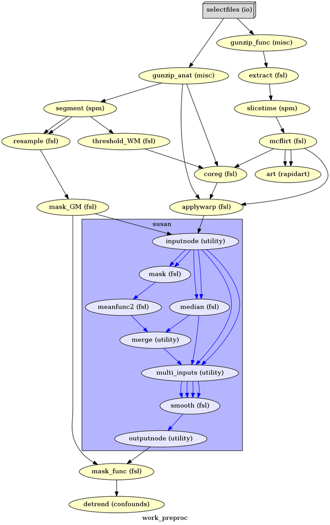

```python
# Create preproc output graph
preproc.write_graph(graph2use='colored', format='png', simple_form=True)

# Visualize the graph
from IPython.display import Image
Image(filename='/output/work_preproc/graph.png', width=750)
```

## Run the Workflow

Now we are ready to run the workflow! Be careful about the `n_procs` parameter if you run a workflow in `'MultiProc'` mode. `n_procs` specifies the number of jobs/cores your computer will use to run the workflow. If this number is too high your computer will try to execute too many things at once and will most likely crash.

**Note**: If you're using a Docker container and FLIRT fails to run without any good reason, you might need to change memory settings in the Docker preferences (6 GB should be enough for this workflow).

```python
preproc.run('MultiProc', plugin_args={'n_procs': 8})
```

```
180514-09:56:56,693 workflow INFO:
	 Workflow work_preproc settings: ['check', 'execution', 'logging', 'monitoring']
180514-09:56:56,726 workflow INFO:
	 Running in parallel.
180514-09:56:56,730 workflow INFO:
	 [MultiProc] Running 0 tasks, and 1 jobs ready. Free memory (GB): 53.94/53.94, Free processors: 8/8.
180514-09:56:56,803 workflow INFO:
	 [Node] Setting-up "work_preproc.selectfiles" in "/output/work_preproc/_subject_id_07/selectfiles".
180514-09:56:56,838 workflow INFO:
	 [Node] Running "selectfiles" ("nipype.interfaces.io.SelectFiles")
180514-09:56:56,860 workflow INFO:
	 [Node] Finished "work_preproc.selectfiles".
180514-09:56:58,732 workflow INFO:
	 [Job 0] Completed (work_preproc.selectfiles).
180514-09:56:58,735 workflow INFO:
	 [MultiProc] Running 0 tasks, and 2 jobs ready. Free memory (GB): 53.94/53.94, Free processors: 8/8.
180514-09:56:58,792 workflow INFO:
	 [Node] Setting-up "work_preproc.gunzip_anat" in "/output/work_preproc/_subject_id_07/gunzip_anat".
180514-09:56:58,790 workflow INFO:
	 [Node] Setting-up "work_preproc.gunzip_func" in "/output/work_preproc/_subject_id_07/gunzip_func".
180514-09:56:58,822 workflow INFO:
	 [Node] Running "gunzip_anat" ("nipype.algorithms.misc.Gunzip")
180514-09:56:58,826 workflow INFO:
	 [Node] Running "gunzip_func" ("nipype.algorithms.misc.Gunzip")
180514-09:56:59,281 workflow INFO:
	 [Node] Finished "work_preproc.gunzip_anat".
180514-09:56:59,647 workflow INFO:
	 [Node] Finished "work_preproc.gunzip_func".
180514-09:57:00,733 workflow INFO:
	 [Job 1] Completed (work_preproc.gunzip_func).
180514-09:57:00,735 workflow INFO:
	 [Job 6] Completed (work_preproc.gunzip_anat).
180514-09:57:00,737 workflow INFO:
	 [MultiProc] Running 0 tasks, and 2 jobs ready. Free memory (GB): 53.94/53.94, Free processors: 8/8.
180514-09:57:00,792 workflow INFO:
	 [Node] Setting-up "work_preproc.segment" in "/output/work_preproc/_subject_id_07/segment".
180514-09:57:00,802 workflow INFO:
	 [Node] Running "segment" ("nipype.interfaces.spm.preprocess.NewSegment")
180514-09:57:00,785 workflow INFO:
	 [Node] Setting-up "work_preproc.extract" in "/output/work_preproc/_subject_id_07/extract".
```

[output cut: 35 more lines]

```
                     Currently running:
                       * work_preproc.mcflirt
                       * work_preproc.segment
180514-09:58:41,977 workflow INFO:
	 [Node] Finished "work_preproc.mcflirt".
180514-09:58:42,833 workflow INFO:
	 [Job 4] Completed (work_preproc.mcflirt).
180514-09:58:42,836 workflow INFO:
	 [MultiProc] Running 1 tasks, and 1 jobs ready. Free memory (GB): 53.74/53.94, Free processors: 7/8.
                     Currently running:
                       * work_preproc.segment
180514-09:58:42,890 workflow INFO:
	 [Node] Setting-up "work_preproc.art" in "/output/work_preproc/_subject_id_07/art".
180514-09:58:42,897 workflow INFO:
	 [Node] Running "art" ("nipype.algorithms.rapidart.ArtifactDetect")
```

[output not shown]

[output cut: 79 more lines]

[output not shown]

```
180514-09:58:44,76 workflow INFO:
	 [Node] Finished "work_preproc.art".
180514-09:58:44,835 workflow INFO:
	 [Job 5] Completed (work_preproc.art).
180514-09:58:44,838 workflow INFO:
	 [MultiProc] Running 1 tasks, and 0 jobs ready. Free memory (GB): 53.74/53.94, Free processors: 7/8.
                     Currently running:
                       * work_preproc.segment
180514-10:00:06,119 workflow INFO:
	 [Node] Finished "work_preproc.segment".
180514-10:00:06,913 workflow INFO:
	 [Job 7] Completed (work_preproc.segment).
180514-10:00:06,921 workflow INFO:
	 [MultiProc] Running 0 tasks, and 2 jobs ready. Free memory (GB): 53.94/53.94, Free processors: 8/8.
180514-10:00:06,991 workflow INFO:
	 [Node] Setting-up "work_preproc.resample" in "/output/work_preproc/_subject_id_07/resample".
180514-10:00:06,993 workflow INFO:
	 [Node] Setting-up "work_preproc.threshold_WM" in "/output/work_preproc/_subject_id_07/threshold_WM".
180514-10:00:07,2 workflow INFO:
	 [Node] Running "threshold_WM" ("nipype.interfaces.fsl.maths.Threshold"), a CommandLine Interface with command:
fslmaths /output/work_preproc/_subject_id_07/segment/c2sub-07_ses-test_T1w.nii -thr 0.5000000000 -bin /output/work_preproc/_subject_id_07/threshold_WM/c2sub-07_ses-test_T1w_thresh.nii180514-10:00:07,2 workflow INFO:
	 [Node] Running "resample" ("nipype.interfaces.fsl.preprocess.FLIRT"), a CommandLine Interface with command:
flirt -in /output/work_preproc/_subject_id_07/segment/c1sub-07_ses-test_T1w.nii -ref /output/work_preproc/_subject_id_07/segment/c1sub-07_ses-test_T1w.nii -out c1sub-07_ses-test_T1w_flirt.nii -omat c1sub-07_ses-test_T1w_flirt.mat -applyisoxfm 4.000000

180514-10:00:07,538 workflow INFO:
	 [Node] Finished "work_preproc.threshold_WM".
180514-10:00:08,913 workflow INFO:
	 [Job 10] Completed (work_preproc.threshold_WM).
180514-10:00:08,916 workflow INFO:
	 [MultiProc] Running 1 tasks, and 1 jobs ready. Free memory (GB): 53.74/53.94, Free processors: 7/8.
                     Currently running:
                       * work_preproc.resample
180514-10:00:08,979 workflow INFO:
	 [Node] Setting-up "work_preproc.coreg" in "/output/work_preproc/_subject_id_07/coreg".
180514-10:00:08,987 workflow INFO:
	 [Node] Running "coreg" ("nipype.interfaces.fsl.preprocess.FLIRT"), a CommandLine Interface with command:
flirt -in /output/work_preproc/_subject_id_07/mcflirt/asub-07_ses-test_task-fingerfootlips_bold_roi_mcf.nii.gz_mean_reg.nii.gz -ref /output/work_preproc/_subject_id_07/gunzip_anat/sub-07_ses-test_T1w.nii -out asub-07_ses-test_task-fingerfootlips_bold_roi_mcf.nii.gz_mean_reg_flirt.nii -omat asub-07_s…
180514-10:00:10,779 workflow INFO:
	 [Node] Finished "work_preproc.resample".
180514-10:00:10,915 workflow INFO:
```

[output cut: 139 more lines]

```
	 [MultiProc] Running 0 tasks, and 1 jobs ready. Free memory (GB): 53.94/53.94, Free processors: 8/8.
180514-10:02:41,108 workflow INFO:
	 [Node] Setting-up "work_preproc.detrend" in "/output/work_preproc/_subject_id_07/detrend".
180514-10:02:41,113 workflow INFO:
	 [Node] Running "detrend" ("nipype.algorithms.confounds.TSNR")
180514-10:02:43,58 workflow INFO:
	 [MultiProc] Running 1 tasks, and 0 jobs ready. Free memory (GB): 53.74/53.94, Free processors: 7/8.
                     Currently running:
                       * work_preproc.detrend
180514-10:02:46,341 workflow INFO:
	 [Node] Finished "work_preproc.detrend".
180514-10:02:47,63 workflow INFO:
	 [Job 20] Completed (work_preproc.detrend).
180514-10:02:47,69 workflow INFO:
	 [MultiProc] Running 0 tasks, and 0 jobs ready. Free memory (GB): 53.94/53.94, Free processors: 8/8.
```

```
<networkx.classes.digraph.DiGraph at 0x7f026449ba58>
```

## Inspect output

What did we actually do? Let's look at all the data that was created.

```python
!tree /output/work_preproc/ -I '*js|*json|*pklz|_report|*dot|*html|*txt|*.m'
```

```
/output/work_preproc/
├── graph.png
├── _subject_id_07
│   ├── applywarp
│   │   ├── asub-07_ses-test_task-fingerfootlips_bold_roi_mcf_flirt.mat
│   │   └── asub-07_ses-test_task-fingerfootlips_bold_roi_mcf_flirt.nii
│   ├── art
│   │   ├── mask.asub-07_ses-test_task-fingerfootlips_bold_roi_mcf.nii.gz
│   │   └── plot.asub-07_ses-test_task-fingerfootlips_bold_roi_mcf.svg
│   ├── coreg
│   │   ├── asub-07_ses-test_task-fingerfootlips_bold_roi_mcf.nii.gz_mean_reg_flirt.mat
│   │   └── asub-07_ses-test_task-fingerfootlips_bold_roi_mcf.nii.gz_mean_reg_flirt.nii
│   ├── detrend
│   │   ├── detrend.nii.gz
│   │   ├── mean.nii.gz
│   │   ├── stdev.nii.gz
│   │   └── tsnr.nii.gz
│   ├── extract
│   │   └── sub-07_ses-test_task-fingerfootlips_bold_roi.nii
│   ├── gunzip_anat
│   │   └── sub-07_ses-test_T1w.nii
│   ├── gunzip_func
│   │   └── sub-07_ses-test_task-fingerfootlips_bold.nii
│   ├── mask_func
│   │   └── mapflow
│   │       └── _mask_func0
│   │           └── asub-07_ses-test_task-fingerfootlips_bold_roi_mcf_flirt_smooth_masked.nii
│   ├── mask_GM
│   │   └── c1sub-07_ses-test_T1w_flirt_thresh.nii
│   ├── mcflirt
│   │   ├── asub-07_ses-test_task-fingerfootlips_bold_roi_mcf.nii.gz
│   │   ├── asub-07_ses-test_task-fingerfootlips_bold_roi_mcf.nii.gz_mean_reg.nii.gz
│   │   └── asub-07_ses-test_task-fingerfootlips_bold_roi_mcf.nii.gz.par
│   ├── resample
│   │   ├── c1sub-07_ses-test_T1w_flirt.mat
│   │   └── c1sub-07_ses-test_T1w_flirt.nii
│   ├── segment
│   │   ├── c1sub-07_ses-test_T1w.nii
│   │   ├── c2sub-07_ses-test_T1w.nii
│   │   └── c3sub-07_ses-test_T1w.nii
```

[output cut: 11 more lines]

```
        ├── meanfunc2
        │   └── mapflow
        │       └── _meanfunc20
        │           └── asub-07_ses-test_task-fingerfootlips_bold_roi_mcf_flirt_mask_mean.nii.gz
        ├── median
        │   └── mapflow
        │       └── _median0
        ├── merge
        ├── multi_inputs
        └── smooth
            └── mapflow
                └── _smooth0
                    └── asub-07_ses-test_task-fingerfootlips_bold_roi_mcf_flirt_smooth.nii.gz

34 directories, 29 files
```

But what did we do specifically? Well, let's investigate.

### Motion Correction and Artifact Detection

How much did the subject move in the scanner and where there any outliers in the functional images?

```python
%matplotlib inline
```

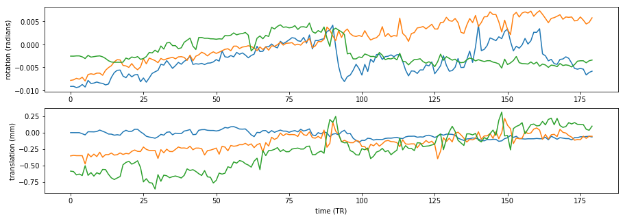

```python
# Plot the motion paramters
import numpy as np
import pylab as plt
par = np.loadtxt('/output/work_preproc/_subject_id_07/mcflirt/'
                 'asub-07_ses-test_task-fingerfootlips_bold_roi_mcf.nii.gz.par')
fig, axes = plt.subplots(2, 1, figsize=(15, 5))
axes[0].set_ylabel('rotation (radians)')
axes[0].plot(par[0:, :3])
axes[1].plot(par[0:, 3:])
axes[1].set_xlabel('time (TR)')
axes[1].set_ylabel('translation (mm)');
```

The motion parameters seems to look ok. What about the detection of artifacts?

```python
# Showing the artifact detection output
from IPython.display import SVG
SVG(filename='/output/work_preproc/_subject_id_07/art/'
    'plot.asub-07_ses-test_task-fingerfootlips_bold_roi_mcf.svg')
```

[figure not shown]

Which volumes are problematic?

```python
outliers = np.loadtxt('/output/work_preproc/_subject_id_07/art/'
                      'art.asub-07_ses-test_task-fingerfootlips_bold_roi_mcf_outliers.txt')
list(outliers.astype('int'))
```

```
[9, 21, 95, 96, 105, 120, 141, 156, 157]
```

### Masks and Probability maps

```python
from nilearn import image as nli
from nilearn.plotting import plot_stat_map
%matplotlib inline
output = '/output/work_preproc/_subject_id_07/'
```

First, let's look at the tissue probability maps.

```python
anat = output + 'gunzip_anat/sub-07_ses-test_T1w.nii'
```

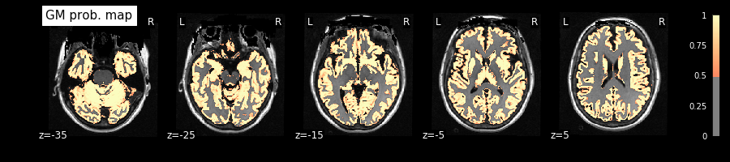

```python
plot_stat_map(
    output + 'segment/c1sub-07_ses-test_T1w.nii', title='GM prob. map',  cmap=plt.cm.magma,
    threshold=0.5, bg_img=anat, display_mode='z', cut_coords=range(-35, 15, 10), dim=-1);
```

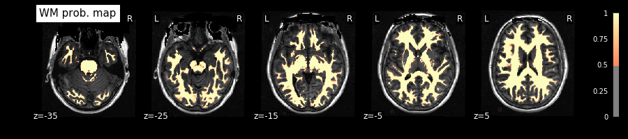

```python
plot_stat_map(
    output + 'segment/c2sub-07_ses-test_T1w.nii', title='WM prob. map', cmap=plt.cm.magma,
    threshold=0.5, bg_img=anat, display_mode='z', cut_coords=range(-35, 15, 10), dim=-1);
```

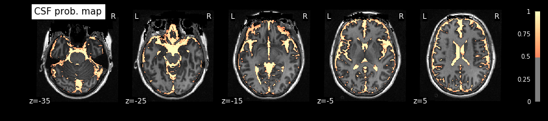

```python
plot_stat_map(
    output + 'segment/c3sub-07_ses-test_T1w.nii', title='CSF prob. map', cmap=plt.cm.magma,
    threshold=0.5, bg_img=anat, display_mode='z', cut_coords=range(-35, 15, 10), dim=-1);
```

And how does the gray matter mask look like that we used on the functional images?

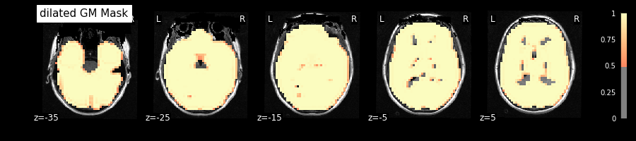

```python
plot_stat_map(
    output + 'mask_GM/c1sub-07_ses-test_T1w_flirt_thresh.nii', title='dilated GM Mask', cmap=plt.cm.magma,
    threshold=0.5, bg_img=anat, display_mode='z', cut_coords=range(-35, 15, 10), dim=-1);
```

### Functional Image transformations

Let's also investigate the transformation that we applied to the functional images.

```python
%matplotlib inline
from nilearn import image as nli
from nilearn.plotting import plot_epi
output = '/output/work_preproc/_subject_id_07/'
```

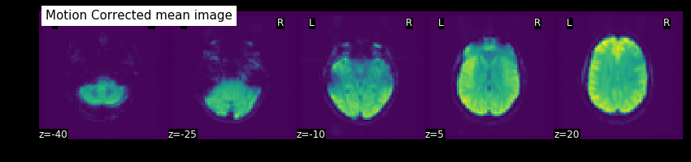

```python
plot_epi(output + 'mcflirt/asub-07_ses-test_task-fingerfootlips_bold_roi_mcf.nii.gz_mean_reg.nii.gz',
         title='Motion Corrected mean image', display_mode='z', cut_coords=range(-40, 21, 15),
         cmap=plt.cm.viridis);
```

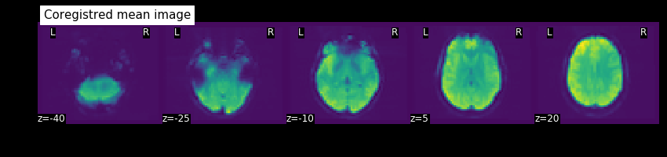

```python
mean = nli.mean_img(output + 'applywarp/asub-07_ses-test_task-fingerfootlips_bold_roi_mcf_flirt.nii')
plot_epi(mean, title='Coregistred mean image', display_mode='z', cut_coords=range(-40, 21, 15),
         cmap=plt.cm.viridis);
```

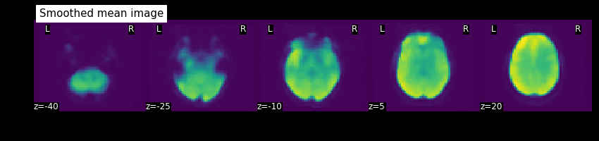

```python
mean = nli.mean_img('/output/work_preproc/susan/_subject_id_07/smooth/mapflow/_smooth0/'
                    'asub-07_ses-test_task-fingerfootlips_bold_roi_mcf_flirt_smooth.nii.gz')
plot_epi(mean, title='Smoothed mean image', display_mode='z', cut_coords=range(-40, 21, 15),
         cmap=plt.cm.viridis);
```

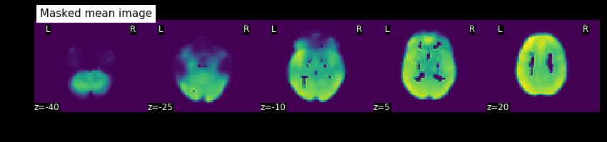

```python
mean = nli.mean_img(output + 'mask_func/mapflow/_mask_func0/'
                    'asub-07_ses-test_task-fingerfootlips_bold_roi_mcf_flirt_smooth_masked.nii')
plot_epi(mean, title='Masked mean image', display_mode='z', cut_coords=range(-40, 21, 15),
         cmap=plt.cm.viridis);
```

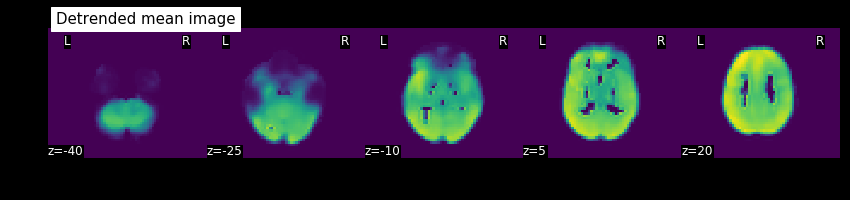

```python
plot_epi(output + 'detrend/mean.nii.gz', title='Detrended mean image', display_mode='z',
         cut_coords=range(-40, 21, 15), cmap=plt.cm.viridis);
```

That's all nice and beautiful, but what did smoothing and detrending actually do to the data?

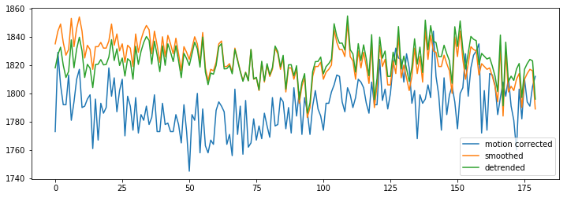

```python
%matplotlib inline
import nibabel as nb
output = '/output/work_preproc/_subject_id_07/'

# Load the relevant datasets
mc = nb.load(output + 'applywarp/asub-07_ses-test_task-fingerfootlips_bold_roi_mcf_flirt.nii')
smooth = nb.load('/output/work_preproc/susan/_subject_id_07/smooth/mapflow/'
                 '_smooth0/asub-07_ses-test_task-fingerfootlips_bold_roi_mcf_flirt_smooth.nii.gz')
detrended_data = nb.load(output + 'detrend/detrend.nii.gz')

# Plot a representative voxel
x, y, z = 32, 34, 43
fig = plt.figure(figsize=(12, 4))
plt.plot(mc.get_data()[x, y, z, :])
plt.plot(smooth.get_data()[x, y, z, :])
plt.plot(detrended_data.get_data()[x, y, z, :])
plt.legend(['motion corrected', 'smoothed', 'detrended']);
```

## Data output with `DataSink`

The results look fine, but we don't need all those temporary files. So let's use Datasink to keep only those files that we actually need for the 1st and 2nd level analysis.

```python
from nipype.interfaces.io import DataSink

# Initiate the datasink node
output_folder = 'datasink_handson'
datasink = Node(DataSink(base_directory='/output/',
                         container=output_folder),
                name="datasink")
```

Now the next step is to specify all the output that we want to keep in our output folder `output`. Make sure to keep:

- from the artifact detection node the outlier file as well as the outlier plot
- from the motion correction node the motion parameters
- from the last node, the detrended functional image

```python
# Connect nodes to datasink here
```

```python
preproc.connect([(art, datasink, [('outlier_files', 'preproc.@outlier_files'),
                                  ('plot_files', 'preproc.@plot_files')]),
                 (mcflirt, datasink, [('par_file', 'preproc.@par')]),
                 (detrend, datasink, [('detrended_file', 'preproc.@func')]),
                 ])
```

## Run the workflow

After adding the datasink folder, let's run the preprocessing workflow again.

```python
preproc.run('MultiProc', plugin_args={'n_procs': 8})
```

```
180514-10:03:32,238 workflow INFO:
	 Workflow work_preproc settings: ['check', 'execution', 'logging', 'monitoring']
180514-10:03:32,274 workflow INFO:
	 Running in parallel.
180514-10:03:32,279 workflow INFO:
	 [MultiProc] Running 0 tasks, and 1 jobs ready. Free memory (GB): 53.94/53.94, Free processors: 8/8.
180514-10:03:32,364 workflow INFO:
	 [Node] Setting-up "work_preproc.selectfiles" in "/output/work_preproc/_subject_id_07/selectfiles".
180514-10:03:32,408 workflow INFO:
	 [Node] Running "selectfiles" ("nipype.interfaces.io.SelectFiles")
180514-10:03:32,417 workflow INFO:
	 [Node] Finished "work_preproc.selectfiles".
180514-10:03:34,279 workflow INFO:
	 [Job 0] Completed (work_preproc.selectfiles).
180514-10:03:34,285 workflow INFO:
	 [MultiProc] Running 0 tasks, and 2 jobs ready. Free memory (GB): 53.94/53.94, Free processors: 8/8.
180514-10:03:34,356 workflow INFO:
	 [Job 1] Cached (work_preproc.gunzip_func).
180514-10:03:34,361 workflow INFO:
	 [Job 6] Cached (work_preproc.gunzip_anat).
180514-10:03:36,354 workflow INFO:
	 [Job 2] Cached (work_preproc.extract).
180514-10:03:36,360 workflow INFO:
	 [Job 7] Cached (work_preproc.segment).
180514-10:03:38,285 workflow INFO:
	 [MultiProc] Running 0 tasks, and 3 jobs ready. Free memory (GB): 53.94/53.94, Free processors: 8/8.
180514-10:03:38,358 workflow INFO:
	 [Job 3] Cached (work_preproc.slicetime).
180514-10:03:38,364 workflow INFO:
	 [Job 8] Cached (work_preproc.resample).
180514-10:03:38,368 workflow INFO:
	 [Job 10] Cached (work_preproc.threshold_WM).
180514-10:03:40,288 workflow INFO:
	 [MultiProc] Running 0 tasks, and 2 jobs ready. Free memory (GB): 53.94/53.94, Free processors: 8/8.
180514-10:03:40,355 workflow INFO:
	 [Job 4] Cached (work_preproc.mcflirt).
180514-10:03:40,361 workflow INFO:
	 [Job 9] Cached (work_preproc.mask_GM).
180514-10:03:42,359 workflow INFO:
	 [Node] Outdated cache found for "work_preproc.art".
180514-10:03:42,365 workflow INFO:
	 [Job 11] Cached (work_preproc.coreg).
180514-10:03:42,364 workflow INFO:
	 [Node] Setting-up "work_preproc.art" in "/output/work_preproc/_subject_id_07/art".
180514-10:03:42,384 workflow INFO:
	 [Node] Outdated cache found for "work_preproc.art".
180514-10:03:42,396 workflow INFO:
	 [Node] Running "art" ("nipype.algorithms.rapidart.ArtifactDetect")
```

[output not shown]

[output cut: 105 more lines]

[output not shown]

```
180514-10:03:43,440 workflow INFO:
	 [Node] Finished "work_preproc.art".
180514-10:03:44,291 workflow INFO:
	 [Job 5] Completed (work_preproc.art).
180514-10:03:44,299 workflow INFO:
	 [MultiProc] Running 0 tasks, and 1 jobs ready. Free memory (GB): 53.94/53.94, Free processors: 8/8.
180514-10:03:44,380 workflow INFO:
	 [Job 12] Cached (work_preproc.applywarp).
180514-10:03:46,294 workflow INFO:
	 [MultiProc] Running 0 tasks, and 2 jobs ready. Free memory (GB): 53.94/53.94, Free processors: 8/8.
180514-10:03:46,370 workflow INFO:
	 [Job 13] Cached (work_preproc.susan.mask).
180514-10:03:46,379 workflow INFO:
	 [Job 15] Cached (work_preproc.susan.median).
180514-10:03:48,296 workflow INFO:
	 [MultiProc] Running 0 tasks, and 1 jobs ready. Free memory (GB): 53.94/53.94, Free processors: 8/8.
180514-10:03:48,369 workflow INFO:
	 [Job 14] Cached (work_preproc.susan.meanfunc2).
180514-10:03:50,366 workflow INFO:
	 [Job 16] Cached (work_preproc.susan.merge).
180514-10:03:52,363 workflow INFO:
	 [Job 17] Cached (work_preproc.susan.multi_inputs).
180514-10:03:54,375 workflow INFO:
	 [Job 18] Cached (work_preproc.susan.smooth).
180514-10:03:56,376 workflow INFO:
	 [Job 19] Cached (work_preproc.mask_func).
180514-10:03:58,374 workflow INFO:
	 [Node] Outdated cache found for "work_preproc.detrend".
180514-10:03:58,380 workflow INFO:
	 [Node] Setting-up "work_preproc.detrend" in "/output/work_preproc/_subject_id_07/detrend".
180514-10:03:58,412 workflow INFO:
	 [Node] Outdated cache found for "work_preproc.detrend".
180514-10:03:58,422 workflow INFO:
	 [Node] Running "detrend" ("nipype.algorithms.confounds.TSNR")
180514-10:04:00,304 workflow INFO:
	 [MultiProc] Running 1 tasks, and 0 jobs ready. Free memory (GB): 53.74/53.94, Free processors: 7/8.
                     Currently running:
                       * work_preproc.detrend
180514-10:04:03,844 workflow INFO:
	 [Node] Finished "work_preproc.detrend".
180514-10:04:04,308 workflow INFO:
	 [Job 20] Completed (work_preproc.detrend).
180514-10:04:04,312 workflow INFO:
	 [MultiProc] Running 0 tasks, and 1 jobs ready. Free memory (GB): 53.94/53.94, Free processors: 8/8.
180514-10:04:04,381 workflow INFO:
	 [Node] Setting-up "work_preproc.datasink" in "/output/work_preproc/_subject_id_07/datasink".
180514-10:04:04,391 workflow INFO:
	 [Node] Running "datasink" ("nipype.interfaces.io.DataSink")
180514-10:04:04,400 workflow INFO:
	 [Node] Finished "work_preproc.datasink".
180514-10:04:06,311 workflow INFO:
	 [Job 21] Completed (work_preproc.datasink).
180514-10:04:06,318 workflow INFO:
	 [MultiProc] Running 0 tasks, and 0 jobs ready. Free memory (GB): 53.94/53.94, Free processors: 8/8.
```

```
<networkx.classes.digraph.DiGraph at 0x7f02327e86d8>
```

Let's look now at the output of this datasink folder.

```python
!tree /output/datasink_handson -I '*js|*json|*pklz|_report|*dot|*html|*txt|*.m'
```

```
/output/datasink_handson
└── preproc
    └── _subject_id_07
        ├── asub-07_ses-test_task-fingerfootlips_bold_roi_mcf.nii.gz.par
        ├── detrend.nii.gz
        └── plot.asub-07_ses-test_task-fingerfootlips_bold_roi_mcf.svg

2 directories, 3 files
```

Much better! But we're still not there yet. There are many unnecessary file specifiers that we can get rid off. To do so, we can use `DataSink`'s `substitutions` parameter. For this, we create a list of tuples: on the left, we specify the string that we want to replace and on the right, with what we want to replace it with.

```python
## Use the following substitutions for the DataSink output
substitutions = [('asub', 'sub'),
                 ('_ses-test_task-fingerfootlips_bold_roi_mcf', ''),
                 ('.nii.gz.par', '.par'),
                 ]

# To get rid of the folder '_subject_id_07' and renaming detrend
substitutions += [('_subject_id_%s/detrend' % s,
                   '_subject_id_%s/sub-%s_detrend' % (s, s)) for s in subject_list]
substitutions += [('_subject_id_%s/' % s, '') for s in subject_list]
datasink.inputs.substitutions = substitutions
```

Before we run the preprocessing workflow again, let's first delete the current output folder:

```python
# Delets the current output folder
!rm -rf /output/datasink_handson
```

```python
# Runs the preprocessing workflow again, this time with substitutions
preproc.run('MultiProc', plugin_args={'n_procs': 8})
```

```
180514-10:04:09,718 workflow INFO:
	 Workflow work_preproc settings: ['check', 'execution', 'logging', 'monitoring']
180514-10:04:09,751 workflow INFO:
	 Running in parallel.
180514-10:04:09,755 workflow INFO:
	 [MultiProc] Running 0 tasks, and 1 jobs ready. Free memory (GB): 53.94/53.94, Free processors: 8/8.
180514-10:04:09,831 workflow INFO:
	 [Node] Setting-up "work_preproc.selectfiles" in "/output/work_preproc/_subject_id_07/selectfiles".
180514-10:04:09,872 workflow INFO:
	 [Node] Running "selectfiles" ("nipype.interfaces.io.SelectFiles")
180514-10:04:09,881 workflow INFO:
	 [Node] Finished "work_preproc.selectfiles".
180514-10:04:11,756 workflow INFO:
	 [Job 0] Completed (work_preproc.selectfiles).
180514-10:04:11,759 workflow INFO:
	 [MultiProc] Running 0 tasks, and 2 jobs ready. Free memory (GB): 53.94/53.94, Free processors: 8/8.
180514-10:04:11,813 workflow INFO:
	 [Job 1] Cached (work_preproc.gunzip_func).
180514-10:04:11,818 workflow INFO:
	 [Job 6] Cached (work_preproc.gunzip_anat).
180514-10:04:13,811 workflow INFO:
	 [Job 2] Cached (work_preproc.extract).
180514-10:04:13,817 workflow INFO:
	 [Job 7] Cached (work_preproc.segment).
180514-10:04:15,758 workflow INFO:
	 [MultiProc] Running 0 tasks, and 3 jobs ready. Free memory (GB): 53.94/53.94, Free processors: 8/8.
180514-10:04:15,815 workflow INFO:
	 [Job 3] Cached (work_preproc.slicetime).
180514-10:04:15,820 workflow INFO:
	 [Job 8] Cached (work_preproc.resample).
180514-10:04:15,824 workflow INFO:
	 [Job 10] Cached (work_preproc.threshold_WM).
180514-10:04:17,761 workflow INFO:
	 [MultiProc] Running 0 tasks, and 2 jobs ready. Free memory (GB): 53.94/53.94, Free processors: 8/8.
180514-10:04:17,841 workflow INFO:
	 [Job 4] Cached (work_preproc.mcflirt).
180514-10:04:17,846 workflow INFO:
	 [Job 9] Cached (work_preproc.mask_GM).
180514-10:04:19,815 workflow INFO:
	 [Job 5] Cached (work_preproc.art).
```

[output cut: 33 more lines]

```
	 [Node] Running "datasink" ("nipype.interfaces.io.DataSink")
180514-10:04:37,883 interface INFO:
	 sub: /output/datasink_handson/preproc/_subject_id_07/detrend.nii.gz -> /output/datasink_handson/preproc/sub-07_detrend.nii.gz
180514-10:04:37,887 interface INFO:
	 sub: /output/datasink_handson/preproc/_subject_id_07/asub-07_ses-test_task-fingerfootlips_bold_roi_mcf.nii.gz.par -> /output/datasink_handson/preproc/sub-07.par
180514-10:04:37,889 interface INFO:
	 sub: /output/datasink_handson/preproc/_subject_id_07/art.asub-07_ses-test_task-fingerfootlips_bold_roi_mcf_outliers.txt -> /output/datasink_handson/preproc/art.sub-07_outliers.txt
180514-10:04:37,892 interface INFO:
	 sub: /output/datasink_handson/preproc/_subject_id_07/plot.asub-07_ses-test_task-fingerfootlips_bold_roi_mcf.svg -> /output/datasink_handson/preproc/plot.sub-07.svg
180514-10:04:37,901 workflow INFO:
	 [Node] Finished "work_preproc.datasink".
180514-10:04:39,779 workflow INFO:
	 [Job 21] Completed (work_preproc.datasink).
180514-10:04:39,786 workflow INFO:
	 [MultiProc] Running 0 tasks, and 0 jobs ready. Free memory (GB): 53.94/53.94, Free processors: 8/8.
```

```
<networkx.classes.digraph.DiGraph at 0x7f0265141780>
```

```python
!tree /output/datasink_handson -I '*js|*json|*pklz|_report|*dot|*html|*.m'
```

```
/output/datasink_handson
└── preproc
    ├── art.sub-07_outliers.txt
    ├── plot.sub-07.svg
    ├── sub-07_detrend.nii.gz
    └── sub-07.par

1 directory, 4 files
```

## Run Preprocessing workflow on 6 right-handed subjects

Perfect! Now let's run the whole workflow for right-handed subjects. For this, you just need to change the `subject_list` variable and run again the places where this variable is used (i.e. `sf.iterables` and in `DataSink` `substitutions`.

```python
# Update 'subject_list' and its dependencies here
```

```python
subject_list = ['02', '03', '04', '07', '08', '09']

sf.iterables = [('subject_id', subject_list)]
```

```python
# To get rid of the folder '_subject_id_02' and renaming detrend
substitutions += [('_subject_id_%s/detrend' % s,
                   '_subject_id_%s/sub-%s_detrend' % (s, s)) for s in subject_list]
substitutions += [('_subject_id_%s/' % s, '') for s in subject_list]
datasink.inputs.substitutions = substitutions
```

Now we can run the workflow again, this time for all right-handed subjects in parallel.

```python
# Runs the preprocessing workflow again, this time with substitutions
preproc.run('MultiProc', plugin_args={'n_procs': 8})
```

[output not shown]

[output cut: 413 more lines]

```
	 [MultiProc] Running 7 tasks, and 3 jobs ready. Free memory (GB): 52.54/53.94, Free processors: 1/8.
                     Currently running:
                       * work_preproc.mcflirt
                       * work_preproc.mcflirt
                       * work_preproc.mcflirt
                       * work_preproc.segment
                       * work_preproc.segment
                       * work_preproc.segment
                       * work_preproc.segment
180514-10:07:36,924 workflow INFO:
	 [Node] Finished "work_preproc.mcflirt".
180514-10:07:37,7 workflow INFO:
	 [Node] Setting-up "work_preproc.art" in "/output/work_preproc/_subject_id_04/art".
180514-10:07:37,28 workflow INFO:
	 [Node] Running "art" ("nipype.algorithms.rapidart.ArtifactDetect")
```

[output not shown]

[output cut: 105 more lines]

[output not shown]

```
180514-10:07:38,364 workflow INFO:
	 [Node] Finished "work_preproc.art".
180514-10:07:38,913 workflow INFO:
	 [Job 26] Completed (work_preproc.mcflirt).
180514-10:07:38,916 workflow INFO:
	 [Job 71] Completed (work_preproc.art).
180514-10:07:38,921 workflow INFO:
	 [MultiProc] Running 6 tasks, and 3 jobs ready. Free memory (GB): 52.74/53.94, Free processors: 2/8.
                     Currently running:
                       * work_preproc.mcflirt
                       * work_preproc.mcflirt
                       * work_preproc.segment
                       * work_preproc.segment
                       * work_preproc.segment
                       * work_preproc.segment
180514-10:07:38,991 workflow INFO:
	 [Node] Setting-up "work_preproc.art" in "/output/work_preproc/_subject_id_08/art".180514-10:07:38,992 workflow INFO:
	 [Node] Setting-up "work_preproc.gunzip_func" in "/output/work_preproc/_subject_id_02/gunzip_func".

180514-10:07:39,13 workflow INFO:
	 [Node] Running "art" ("nipype.algorithms.rapidart.ArtifactDetect")180514-10:07:39,20 workflow INFO:
	 [Node] Running "gunzip_func" ("nipype.algorithms.misc.Gunzip")

180514-10:07:39,897 workflow INFO:
	 [Node] Finished "work_preproc.gunzip_func".
```

[output not shown]

[output cut: 105 more lines]

[output not shown]

```
180514-10:07:40,380 workflow INFO:
	 [Node] Finished "work_preproc.mcflirt".
180514-10:07:40,412 workflow INFO:
	 [Node] Finished "work_preproc.art".
180514-10:07:40,917 workflow INFO:
	 [Job 4] Completed (work_preproc.mcflirt).
180514-10:07:40,919 workflow INFO:
	 [Job 27] Completed (work_preproc.art).
180514-10:07:40,922 workflow INFO:
	 [Job 111] Completed (work_preproc.gunzip_func).
180514-10:07:40,927 workflow INFO:
	 [MultiProc] Running 5 tasks, and 3 jobs ready. Free memory (GB): 52.94/53.94, Free processors: 3/8.
                     Currently running:
                       * work_preproc.mcflirt
                       * work_preproc.segment
                       * work_preproc.segment
                       * work_preproc.segment
                       * work_preproc.segment
180514-10:07:40,998 workflow INFO:
	 [Node] Setting-up "work_preproc.art" in "/output/work_preproc/_subject_id_09/art".
180514-10:07:41,0 workflow INFO:
	 [Node] Setting-up "work_preproc.extract" in "/output/work_preproc/_subject_id_02/extract".
180514-10:07:41,5 workflow INFO:
	 [Node] Running "art" ("nipype.algorithms.rapidart.ArtifactDetect")180514-10:07:41,12 workflow INFO:
	 [Node] Running "extract" ("nipype.interfaces.fsl.utils.ExtractROI"), a CommandLine Interface with command:
fslroi /output/work_preproc/_subject_id_02/gunzip_func/sub-02_ses-test_task-fingerfootlips_bold.nii /output/work_preproc/_subject_id_02/extract/sub-02_ses-test_task-fingerfootlips_bold_roi.nii 4 -1

180514-10:07:41,37 workflow INFO:
	 [Node] Setting-up "work_preproc.gunzip_anat" in "/output/work_preproc/_subject_id_02/gunzip_anat".
180514-10:07:41,62 workflow INFO:
	 [Node] Running "gunzip_anat" ("nipype.algorithms.misc.Gunzip")
180514-10:07:41,499 workflow INFO:
	 [Node] Finished "work_preproc.extract".
180514-10:07:41,618 workflow INFO:
	 [Node] Finished "work_preproc.gunzip_anat".
180514-10:07:42,213 workflow INFO:
	 [Node] Finished "work_preproc.art".
180514-10:07:42,921 workflow INFO:
	 [Job 5] Completed (work_preproc.art).
180514-10:07:42,923 workflow INFO:
```

[output cut: 365 more lines]

```
	 [Node] Finished "work_preproc.mcflirt".
180514-10:09:57,61 workflow INFO:
	 [Job 114] Completed (work_preproc.mcflirt).
180514-10:09:57,64 workflow INFO:
	 [MultiProc] Running 5 tasks, and 1 jobs ready. Free memory (GB): 52.94/53.94, Free processors: 3/8.
                     Currently running:
                       * work_preproc.coreg
                       * work_preproc.coreg
                       * work_preproc.coreg
                       * work_preproc.coreg
                       * work_preproc.segment
180514-10:09:57,128 workflow INFO:
	 [Node] Setting-up "work_preproc.art" in "/output/work_preproc/_subject_id_02/art".
180514-10:09:57,136 workflow INFO:
	 [Node] Running "art" ("nipype.algorithms.rapidart.ArtifactDetect")
```

[output not shown]

[output cut: 105 more lines]

[output not shown]

```
180514-10:09:58,396 workflow INFO:
	 [Node] Finished "work_preproc.art".
180514-10:09:59,62 workflow INFO:
	 [Job 115] Completed (work_preproc.art).
180514-10:09:59,66 workflow INFO:
	 [MultiProc] Running 5 tasks, and 0 jobs ready. Free memory (GB): 52.94/53.94, Free processors: 3/8.
                     Currently running:
                       * work_preproc.coreg
                       * work_preproc.coreg
                       * work_preproc.coreg
                       * work_preproc.coreg
                       * work_preproc.segment
180514-10:11:00,385 workflow INFO:
	 [Node] Finished "work_preproc.coreg".
180514-10:11:01,116 workflow INFO:
	 [Job 11] Completed (work_preproc.coreg).
180514-10:11:01,120 workflow INFO:
	 [MultiProc] Running 4 tasks, and 1 jobs ready. Free memory (GB): 53.14/53.94, Free processors: 4/8.
                     Currently running:
                       * work_preproc.coreg
                       * work_preproc.coreg
                       * work_preproc.coreg
                       * work_preproc.segment
180514-10:11:01,184 workflow INFO:
	 [Node] Setting-up "work_preproc.applywarp" in "/output/work_preproc/_subject_id_09/applywarp".
180514-10:11:01,194 workflow INFO:
	 [Node] Running "applywarp" ("nipype.interfaces.fsl.preprocess.FLIRT"), a CommandLine Interface with command:
flirt -in /output/work_preproc/_subject_id_09/mcflirt/asub-09_ses-test_task-fingerfootlips_bold_roi_mcf.nii.gz -ref /output/work_preproc/_subject_id_09/gunzip_anat/sub-09_ses-test_T1w.nii -out asub-09_ses-test_task-fingerfootlips_bold_roi_mcf_flirt.nii -omat asub-09_ses-test_task-fingerfootlips_bold…
180514-10:11:03,120 workflow INFO:
	 [MultiProc] Running 5 tasks, and 0 jobs ready. Free memory (GB): 52.94/53.94, Free processors: 3/8.
                     Currently running:
                       * work_preproc.applywarp
                       * work_preproc.coreg
                       * work_preproc.coreg
                       * work_preproc.coreg
                       * work_preproc.segment
180514-10:11:16,668 workflow INFO:
	 [Node] Finished "work_preproc.segment".
180514-10:11:17,132 workflow INFO:
	 [Job 117] Completed (work_preproc.segment).
```

[output cut: 902 more lines]

```
	 [Node] Running "datasink" ("nipype.interfaces.io.DataSink")
180514-10:14:05,388 interface INFO:
	 sub: /output/datasink_handson/preproc/_subject_id_02/asub-02_ses-test_task-fingerfootlips_bold_roi_mcf.nii.gz.par -> /output/datasink_handson/preproc/sub-02.par
180514-10:14:05,391 interface INFO:
	 sub: /output/datasink_handson/preproc/_subject_id_02/detrend.nii.gz -> /output/datasink_handson/preproc/sub-02_detrend.nii.gz
180514-10:14:05,394 interface INFO:
	 sub: /output/datasink_handson/preproc/_subject_id_02/art.asub-02_ses-test_task-fingerfootlips_bold_roi_mcf_outliers.txt -> /output/datasink_handson/preproc/art.sub-02_outliers.txt
180514-10:14:05,396 interface INFO:
	 sub: /output/datasink_handson/preproc/_subject_id_02/plot.asub-02_ses-test_task-fingerfootlips_bold_roi_mcf.svg -> /output/datasink_handson/preproc/plot.sub-02.svg
180514-10:14:05,402 workflow INFO:
	 [Node] Finished "work_preproc.datasink".
180514-10:14:07,304 workflow INFO:
	 [Job 131] Completed (work_preproc.datasink).
180514-10:14:07,312 workflow INFO:
	 [MultiProc] Running 0 tasks, and 0 jobs ready. Free memory (GB): 53.94/53.94, Free processors: 8/8.
```

```
<networkx.classes.digraph.DiGraph at 0x7f0265141b38>
```

Now we're ready for the next section Hands-on 2: How to create a fMRI analysis workflow!

[Home](https://miykael.github.io/nipype_tutorial/) | [github](https://github.com/miykael/nipype_tutorial) | [Nipype](http://nipype.readthedocs.io)